# Peer Assessment One

Dr Paul Fergus

16/10/2014

## Load the required libraries

```r
#ggplo2 is a plotting system for R, based on the grammer of graphics, which tries to take the good parts of base and lattice graphics and none of the bad parts. It takes care of many of the fiddly detials that make plotting a hassele (like drawing legents) as well as providing a powerful model of graphics that makes it each to produce complex multi-layered graphics.
library(ggplot2)
#The Hmisc package contains many functions useful for data analysis, high-level graphics, utility operations, functions for computing sample size and power, importing datasets, imputing missing values, advanced table making, variable clustering, character string manipulation, conversion of R objects to LaTeX code, and recoding variables. In this project we are utilising this package to impute missing values in our dataset.
library(Hmisc)
```

## Loading and preprocessing the data

1. Load the data (i.e. read.csv()) This code first checks to see if the csv file exists. If it does not exist then read the csv from the zip file.

```r
if(!file.exists("./data/activity.csv")){
  data <- read.table(
    unz("./data/repdata-data-activity.zip",
      "activity.csv"), sep=",", header=T, na.string="NA")
}
```

2. Process/transform the data (if necessary) into a format suitable for your analysis. This is one a small dataset and the column headings are labeled well and easy to understand. Later on in the code we will be adding additional columns for specific processing on the data.

## What is mean total number of steps taken per day?

1. Make a histogram of the total number of steps taken each day

```
## stat_bin: binwidth defaulted to range/30. Use 'binwidth = x' to adjust this.
```

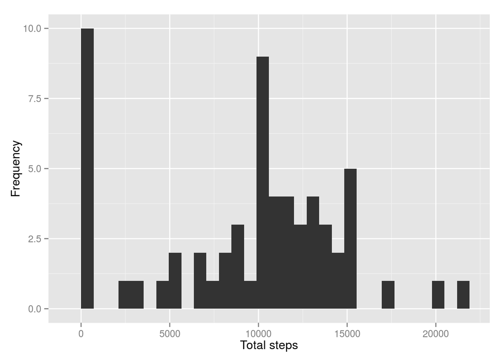

```r
#Use the tapply function. The tapply function is useful when we need to break up a vector inot groups defined by some classifying factor, compute a function on the subsets, and return the results in a convinient form. You can even specify multiple factors as the grouping variables, for example treatment and sex. In our example we are using steps and date, i.e. the number of steps taken per day. The function we are using is the sum, given that we want to know what the total number of steps take per day is. We would also like to remove any missing values.
total.steps <- tapply(data$steps, data$date, sum, na.rm = T)
#qplot is the basic plotting function in the ggplot2 package, designed to be familiar if you are used to plot from the base package. It is a convenient wrapper for creating a number of different types of plots using a consistent calling scheme.
qplot(total.steps, xlab = "Total steps", ylab="Frequency")
```

2. Calculate and report the mean and median total number of steps taken per day

```r
#Find out what the mean total steps for each day is.
mean(total.steps)
```

```
## [1] 9354.23
```

```r
#Find out what the median total steps for each day is.
median(total.steps)
```

```
## [1] 10395
```

## What is the average daily activity pattern?

1. Make a time series plot (i.e. type = “l”) of the 5-minute interval (x-axis) and the average number of steps taken, averaged across all days (y-axis)

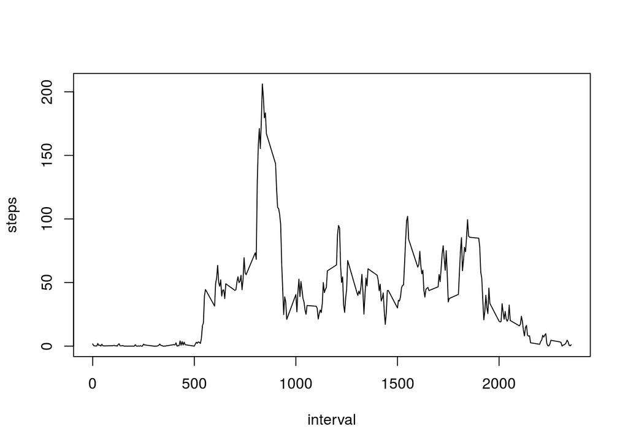

```r
#Find out the average number of steps taken per five minute interval for each ofthe days. The aggreggate function splits the data into subsets, computes summary statistics for each, and returns the result in a convenient form. In our instance it calculates the mean number of steps per interval period (5 minute blocks), across all of the days.
steps.interval <- aggregate(steps ~ interval, data = data, FUN=mean)
#The plot function is a generic function for plotting of R objects.
plot(steps.interval, type="l")
```

2. Which 5-minute interval, on average across all the days in the dataset, contains the maximum number of steps?

```r
#Find out which of all the 5 minute intervals on average across all days has the maximum number of steps. Using the which.max function and the average number of steps it is possible to determine the location, i.e. index, of the maximum of a numeric (or logical) vector.
steps.interval$interval[which.max(steps.interval$steps)]
```

```
## [1] 835
```

## Imputing missing values

Note that there are a number of days/intervals where there are missing values (coded as NA). The presence of missing days may introduce bias into some calculations or summaries of the data.

1. Calculate and report the total number of missing values in the dataset (i.e. the total number of rows with NAs)

```r
#Using the sum function and the is.na across the dataset will tell us how many missing values we have in our dataset.
sum(is.na(data))
```

```
## [1] 2304
```

2. Devise a strategy for filling in all of the missing values in the dataset. The strategy does not need to be sophisticated. For example, you could use the mean/median for that day, or the mean for that 5-minute interval, etc.

```r
#Clone the dataset before we begin to work on it (we do not necessarily want to alter the original dataset)
imputed.data <- data
```

3. Create a new dataset that is equal to the original dataset but with the missing data filled in.

```r
#Using the with function allows us to evaluate an R expression in an environment constructed from the data and modify the original data. Here our imputed.data is used as our environment and impute uses steps from that environment to compute a mean value and replace that value. The impute function involves filling the NAs with constants, with a specified single valued fuunction of the non-NAs, or from a sample (with replacement) from the non-NA values. Basically this code replaces our missing values with mean values from our non-NA values.
imputed.data$steps <- with(imputed.data, impute(steps,mean))
```

4. Make a histogram of the total number of steps taken each day and Calculate and report the mean and median total number of steps taken per day. Do these values differ from the estimates from the first part of the assignment? What is the impact of imputing missing data on the estimates of the total daily number of steps?

```r
#Similar to our code for total.steps above, calculate the number of steps taken each day using our new imputed dataset. Work out what hte mean and median total number of steps taken per day and compate these new imputed mean and median values from the previous dataset that contained the missing values. The values differ however this are not significant changes
total.imputed.steps <- tapply(imputed.data$steps, imputed.data$date, sum)
#Calculate the mean and median values for both the original and imputed datasets.
mean(total.steps)
```

```
## [1] 9354.23
```

```r
mean(total.imputed.steps)
```

```
## [1] 10766.19
```

```r
median(total.steps)
```

```
## [1] 10395
```

```r
median(total.imputed.steps)
```

```
## [1] 10766.19
```

```
## stat_bin: binwidth defaulted to range/30. Use 'binwidth = x' to adjust this.
```

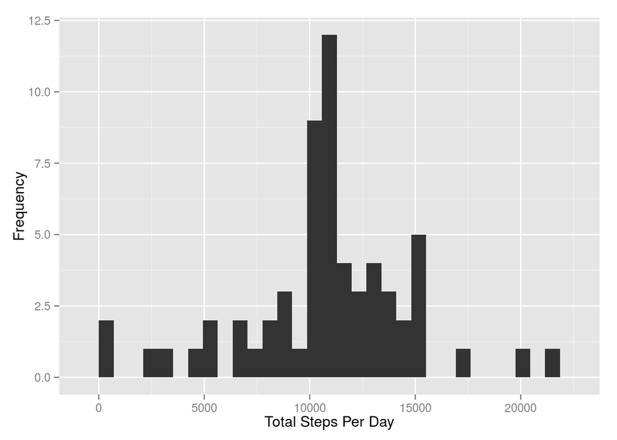

```r
#qplot is the basic plotting function in the ggplot2 package, designed to be familiar if you are used to plot from the base package. It is a convenient wrapper for creating a number of different types of plots using a consistent calling scheme.
qplot(total.imputed.steps, xlab="Total Steps Per Day", ylab="Frequency")
```

```
## stat_bin: binwidth defaulted to range/30. Use 'binwidth = x' to adjust this.
```

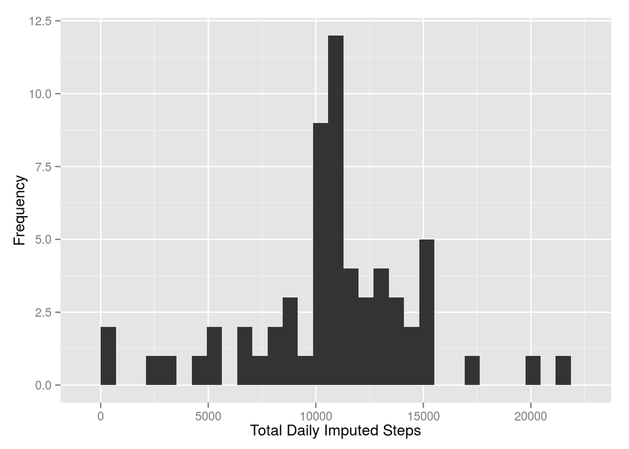

```r
#Use the tapply function. The tapply function is useful when we need to break up a vector inot groups defined by some classifying factor, compute a function on the subsets, and return the results in a convinient form. You can even specify multiple factors as the grouping variables, for example treatment and sex. In our example we are using steps and date, i.e. the number of steps taken per day. The function we are using is the sum, given that we want to know what the total number of steps take per day is. We would also like to remove any missing values.
total.daily.imputed.steps <- tapply(imputed.data$steps, imputed.data$date, sum, na.rm = T)
#qplot is the basic plotting function in the ggplot2 package, designed to be familiar if you are used to plot from the base package. It is a convenient wrapper for creating a number of different types of plots using a consistent calling scheme.
qplot(total.daily.imputed.steps, xlab = "Total Daily Imputed Steps", ylab="Frequency")
```

## Are there differences in activity patterns between weekdays and weekends?

For this part the weekdays() function may be of some help here. Use the dataset with the filled-in missing values for this part.

1. Create a new factor variable in the dataset with two levels – “weekday” and “weekend” indicating whether a given date is a weekday or weekend day.

```r
#Create a function that we can use in sapply that iterates assigns a weekday or weekend factor to our data based on date so that we can compate activity in the weekdays and weekend.
day.type <- function(date){
  if(weekdays(as.Date(date)) %in% c("Saturday", "Sunday")){
    "weekend"
  }else{
    "weekday"
  }
}
#Using sapply date each of the dates in the data set and determine with the date falls with a weekday or weekend. The lapply function returns a list of the same length as X, each eleement of which is the result of applying FUN to the corresponding element of X. sapply is a user-friendly version and wrapper of lapply by default returning a vectro, matrix or, if simplify = "array", an arrray if appropriate.
data$day.type <- as.factor(sapply(data$date, day.type))
#Do the same for our new imputed dataset.
imputed.data$day.type <- as.factor(sapply(imputed.data$date, day.type))
```

2. Make a panel plot containing a time series plot (i.e. type = “l”) of the 5-minute interval (x-axis) and the average number of steps taken, averaged across all weekday days or weekend days (y-axis). The plot should look something like the following, which was creating using simulated data:

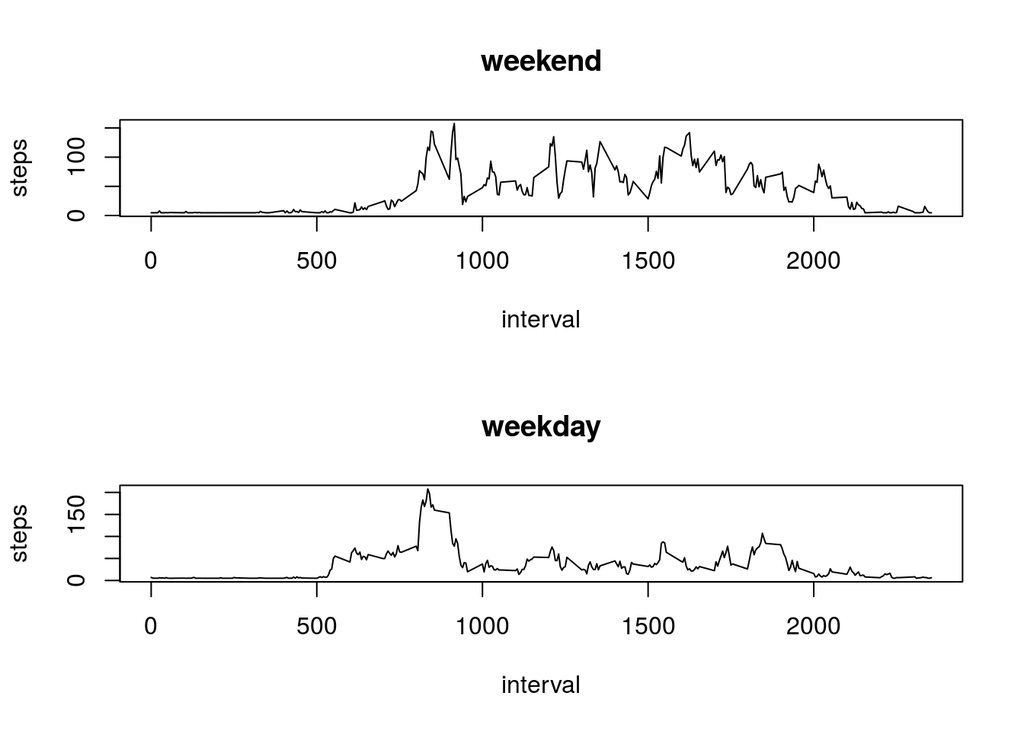

```r
par(mfrow = c(2,1))
#Iterate through each type
for(type in c("weekend", "weekday")){
  #Find out the average number of steps taken per five minute interval for each ofthe days, subsetted by weekday and weekend. The aggreggate function splits the data into subsets, computes summary statistics for each, and returns the result in a convenient form. In our instance it calculates the mean number of steps per interval period (5 minute blocks), across all of the days.
  steps.type <- aggregate(steps~interval, data = imputed.data, subset = imputed.data$day.type  == type, FUN=mean)
  #Plot the weekend and weekday activity
  plot(steps.type, type="l", main=type)
}
```